# Olympic Games

Sayra Moore, Andrea Piolini, Sabina Shahbazzade, Caroline Sklaver, Spencer Staub

11/29/2019

# 1 Introduction and Project 1 Recap

```
## 'data.frame':    271116 obs. of  15 variables:
##  $ ID    : int  1 2 3 4 5 5 5 5 5 5 ...
##  $ Name  : Factor w/ 134732 levels "  Gabrielle Marie \"Gabby\" Adcock (White-)",..: 8 9 44318 29412 21470 21470 21470 21470 21470 21470 ...
##  $ Sex   : Factor w/ 2 levels "F","M": 2 2 2 2 1 1 1 1 1 1 ...
##  $ Age   : int  24 23 24 34 21 21 25 25 27 27 ...
##  $ Height: int  180 170 NA NA 185 185 185 185 185 185 ...
##  $ Weight: num  80 60 NA NA 82 82 82 82 82 82 ...
##  $ Team  : Factor w/ 1184 levels "30. Februar",..: 199 199 273 278 705 705 705 705 705 705 ...
##  $ NOC   : Factor w/ 230 levels "AFG","AHO","ALB",..: 42 42 56 56 146 146 146 146 146 146 ...
##  $ Games : Factor w/ 51 levels "1896 Summer",..: 38 49 7 2 37 37 39 39 40 40 ...
##  $ Year  : int  1992 2012 1920 1900 1988 1988 1992 1992 1994 1994 ...
##  $ Season: Factor w/ 2 levels "Summer","Winter": 1 1 1 1 2 2 2 2 2 2 ...
##  $ City  : Factor w/ 42 levels "Albertville",..: 6 18 3 27 9 9 1 1 17 17 ...
##  $ Sport : Factor w/ 66 levels "Aeronautics",..: 9 33 25 62 54 54 54 54 54 54 ...
##  $ Event : Factor w/ 765 levels "Aeronautics Mixed Aeronautics",..: 160 398 349 710 623 619 623 619 623 619 ...
##  $ Medal : Factor w/ 3 levels "Bronze","Gold",..: NA NA NA 2 NA NA NA NA NA NA ...
```

There are four limitations in our dataset:

1. The dataset is not complete. There are many NAs for Age, Height, Weight.
2. It does not contain the country hosting the event, it has only the city of event.
3. More information on the country hosting the event and on the ethnicity of the athletes would be beneficial
4. Women did not begin participating until the 1900 Paris Olympics

In addition, in order to make our analysis more interesting, we decided to add the Gross Domestic Product (GDP) of each country (when available) to our data frame. We retrieved that data from a GDP dataset available on the World Bank website. This dataset contains most of the GDPs for most countries in the world from 1960 to 2018. The dataset is rather complete, although it contain several NAs, especially for small and poor countries.

In this project, we used different types of inferential statistic, such as ANOVA test and t-test, to analyze our data and infer insightful conclusions. Moreover, we used various supervised and unsupervised machine learning techniques to make predictions and discover, visualize, and explore patterns in the Olympics dataset. The project focuses on three main SMART questions:

**1. SMART Question 1: Does the hosting team have an advantage?**

**2. SMART Question 2: Does height, age, and weight determine if an Olympic athlete wins a medal?**

**3. SMART Question 3: How does GDP determine statistics in the Olympics? Is GDP a good predictor?**

## 1.1 Descriptive Statistics

Before diving into the analysis, we included some graphs from the previous part as a refresher for the reader. The following graphs display the main descriptive statistics that are necessary to understand the dataset and our analysis.

### 1.1.1 Medals

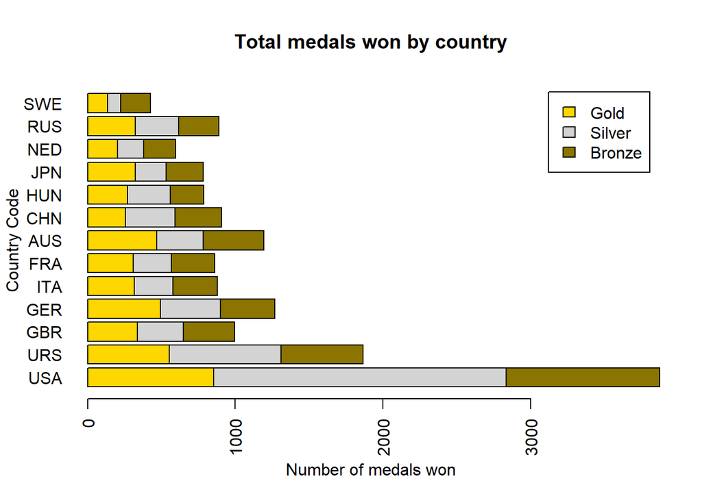

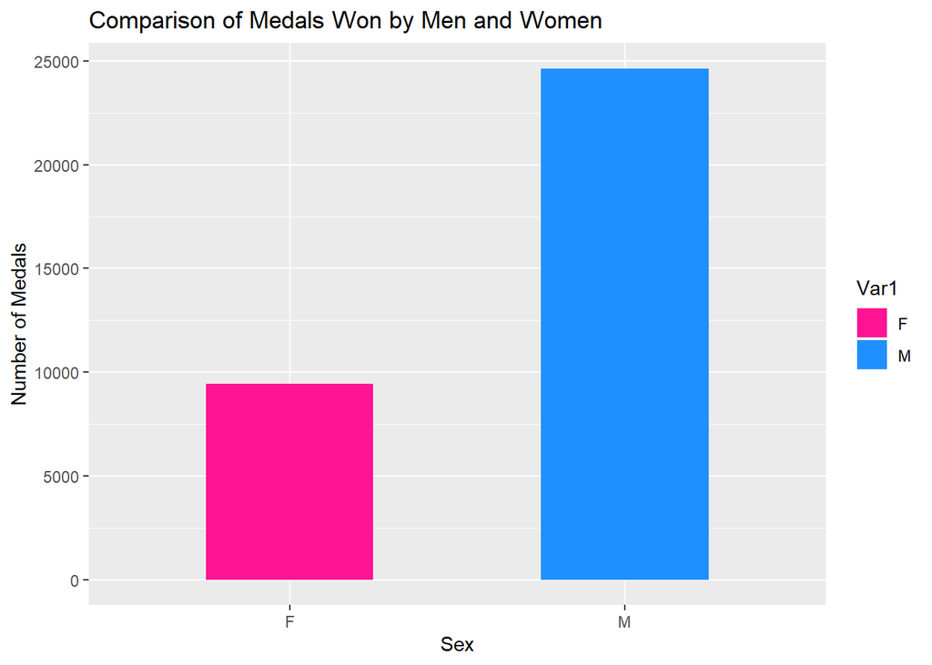

The first graph is a representation of top countries total medals earned by medal type. This clearly shows teams that have dominated the 29 Olympic games. The second graph displays the number of medals won by men and women. From the graph, it is clear that men won more medals than women, where number of medals won by men more than 15,000 and women less than 10,000. One reason of less medals won by women was that women did not participated Olympic games before 1900.

### 1.1.2 Athletes Participation Over 120 Years of Summer Olympic Games

The following graph displays the number of female and male athletes who participated to the Olympics over time:

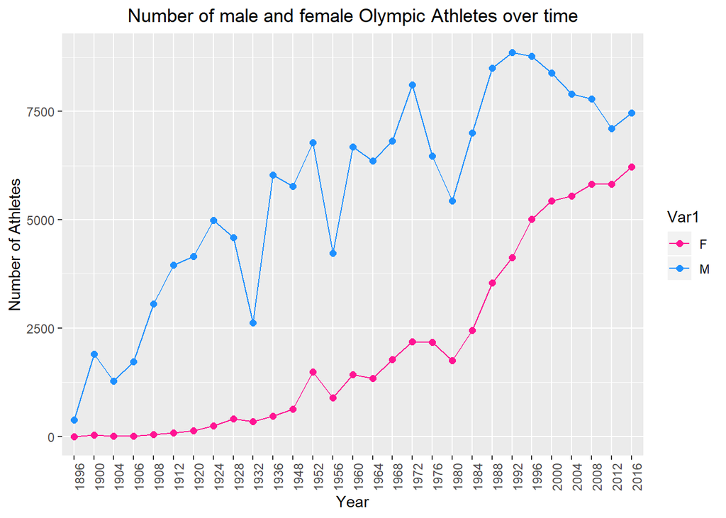

### 1.1.3 Participation by Sport

The following graphs show participation by sport:

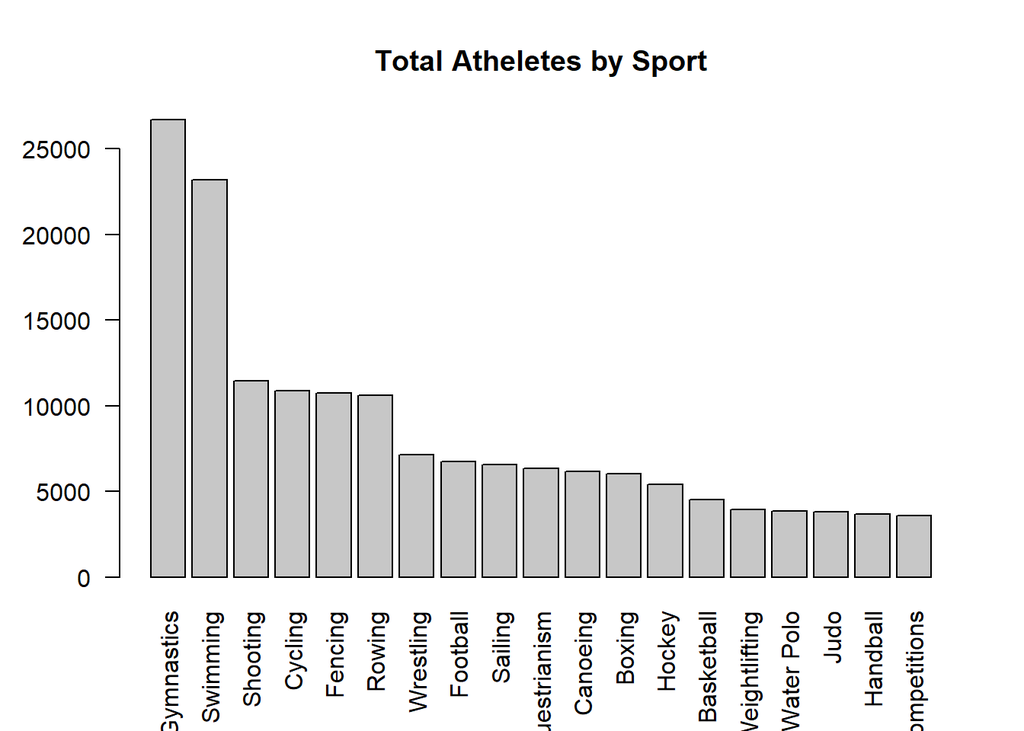

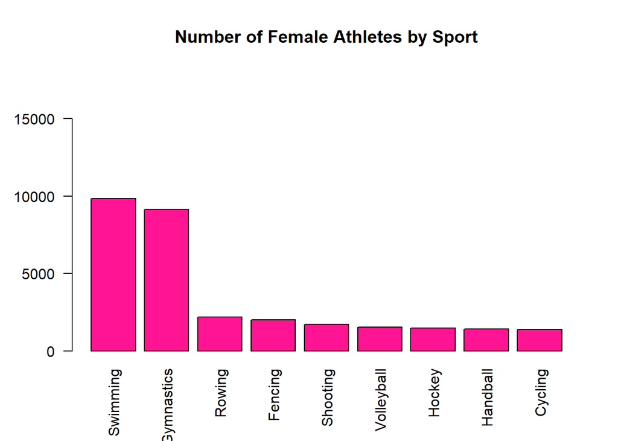

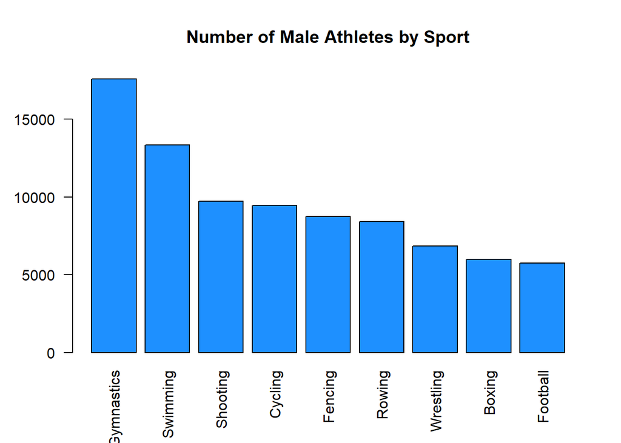

We can also conclude from our participation distribution by sports graphs that gymnastics and swimming are by far the most popular sports of the Olympics, however, for females the two aforementioned sports categories make up a predominant amount of participation.

## 1.2 Histograms of Age, Height, Weight

We also included Histograms to view the distribution of Age, Height, and Weight for all Olympic Athletes. This is useful to determine the distribution.

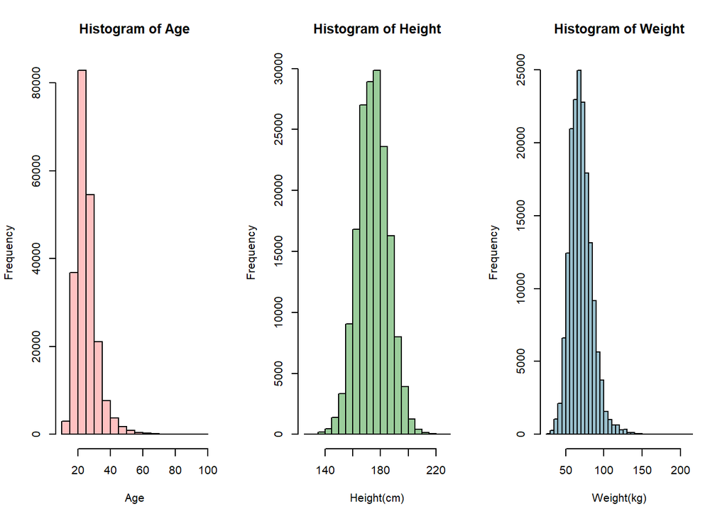

As we can see from the plots, Age and weight are a bit right-skewed, height is very normal. These distributions do not vary greatly when looking at males and females separately.

# 2 SMART QUESTION I:

## 2.1 Does hosting team have an advantage? Do medals won in years previous affect medals won in future olympics (ANOVA) - Do teams have ‘streaks’ of wins? Before/after hosting change in mean medals won?

In this model we will use ANOVA to measure whether hosting the Olympics has an effect on the amount of medals won, as well as the average amount of medals won per evernt (mean). This analysis will be preformed on eight countries with two years before the host event and two years after event. We predict the host country will obtian more medals in their host year and also show an increased medal count in the Olympic events after their host event. To confirm this prediction we will be looking for a low and positive correlation between the event before and host year and a medium to high correlation between the hosting year and event after.

### 2.1.1 ANOVA Results Summarized

**Italy:**

Results from the ANOVA test indicate high and slightly positive correlation between 1960 (host) and 1956 (Year before host), as well as a high and slightly positive correlation between 1960 and 1964 (Year after host). This suggests that the means of the before, host and after years are similar and slightly increasing over time. We can conclude that host year does slightly effect medals won and year after given the lower correlations between host year and 1952/1968.

**Japan:**

Results from the ANOVA test indicate high and slightly positive correlation between 1964 (host) and 1960 (Year before host), as well as a low and slightly positive correlation between 1964 and 1968 (Year after host). This suggest that the means of before and host years are similar and slightly increasing over time, while the means of host and after are dramaticall different and increasing over time. We can conclude that host year does slightly effect medals won and significantly effects the medals won in the year after host.

**Mexico:**

Results from the ANOVA test indicate high and slightly positive correlation between 1968 (host) and 1964 (Year before host), as well as moderate, but slightly negative correlation between 1968 and 1972 (Year after host). This suggest that the means of before and host years are similar and slightly increasing over time, while the means of host and after are dramaticall different and decreasing over time. We can conclude that host year does slightly effect medals won and significantly (but negatively) effects the medals won in the year after host. This is an anomoly in our data.

**Spain:**

Results from the ANOVA test indicate an extremely low and slightly positive correlation between 1992 (host) and 1988 (Year before host), as well as moderate and slightly positive correlation between 1992 and 1996 (Year after host). This suggest that the means of before and host years are drastically different and increasing over time, while the means of host and after are more similar and increasing over time. We can conclude that host year does extremely effect medals won and significantly effects the medals won in the year after host as well.

**United States:**

Results from the ANOVA test indicate an extremely high and slightly positive correlation between 1996 (host) and 1992 (Year before host), as well as high and slightly positive correlation between 1992 and 1996 (Year after host). This suggest that the means of before and host years are significantly similar and increasing over time, as well as the means of host and after years. We can conclude that host year does slightly effect medals won and also slightly effects the medals won in the year after host.

**Australia:**

Results from the ANOVA test indicate an extremely high and slightly negative correlation between 2000 (host) and 1996 (Year before host), as well as high and slightly positive correlation between 2000 and 2004 (Year after host). This suggest that the means of before and host years are significantly similar and decreasing over time, while the means of the host and after years are significantly similar, but increasing over time. We can conclude that host year does not effect medals won and the host year also does not effect the medals won in the year after host.This is an anomoly in our data.

**Greece:**

Results from the ANOVA test indicate an moderate and slightly negative correlation between 2004 (host) and 2000 (Year before host), as well as high and slightly negative correlation between 2004 and 2008 (Year after host). This suggest that the means of before and host years are significantly different and decreasing over time, as well as the means of host and after years (although these means are more similar). We can conclude that host year does not effect medals won and the host year also does not effect the medals won in the year after host. Although one could make an argument that knowing they had a host year coming up Greece was galvanized and therefore won more medals in the year before.

**China:**

Results from the ANOVA test indicate an low and slightly positive correlation between 2008 (host) and 2004 (Year before host), as well as high and slightly positive correlation between 2008 and 2012 (Year after host). This suggest that the means of before and host years are significantly different and increasing over time and the means of host and after years are significantly similar and increasing over time. We can conclude that host year does significantly effect medals won and the host year slighlty effects the medals won in the year after host. China also shows that their medal winning streak continues for at least two years after their host. Hosting may have galvanized the people or government into a higher Olympic participation.

### 2.1.2 Graphic Examples of Medals won from Greece and China

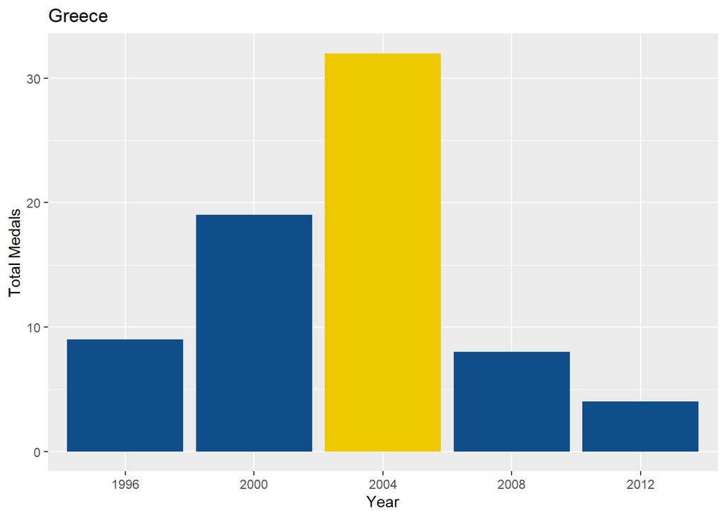

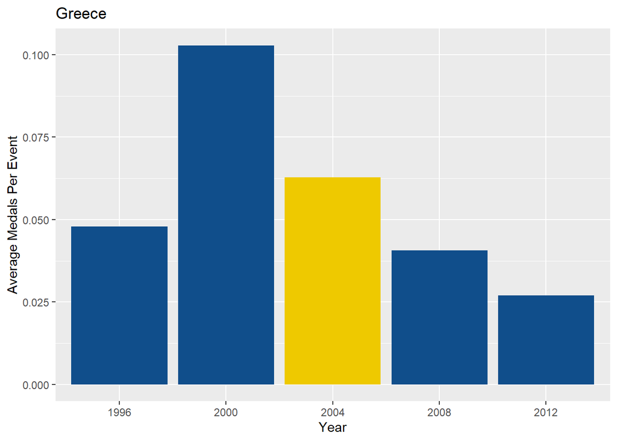

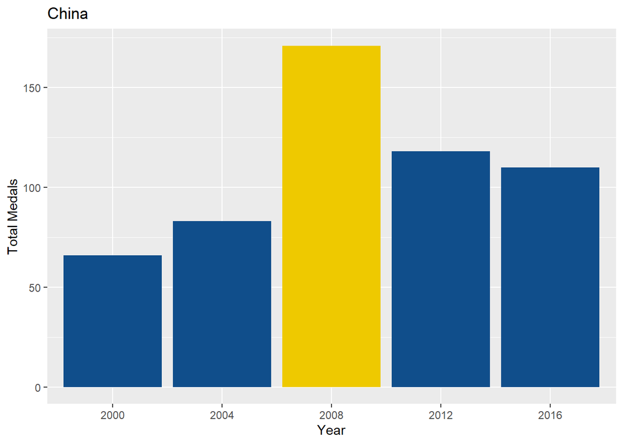

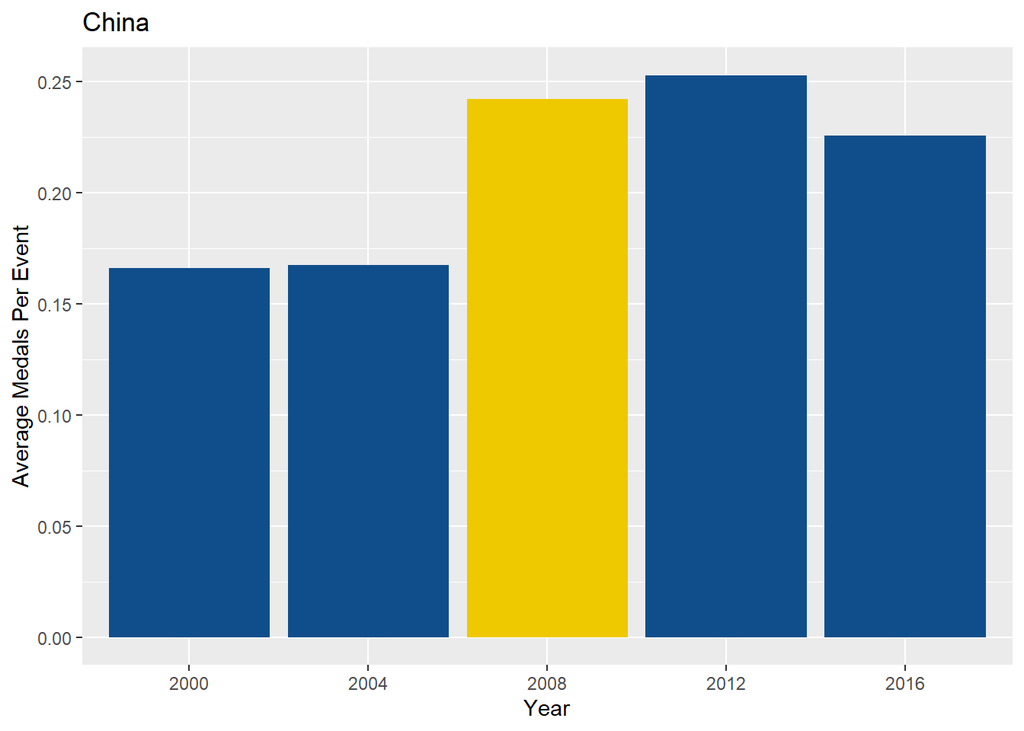

**Greece:**

Greece shows an increase in medal count in the year they host, however, they show a decrease in average medals won per event. We can conclude that Greece increased its participation in their host year, which caused them to win more medals. Greece also does not exibit “host effect” in the subsequent years after hosting.

**China:**

China shows a dreamatic increase in medals won and average medals won per event in their host year. They also exhibit the “host effect” in subsequent years by doing better or similar to their host year and significantly better than the years prior to hosting - in terms of medals won per event.

# 3 SMART QUESTION II:

## 3.1 Does age, height, and weight determine whether an athlete wins an olympic medal?

### 3.1.1 Correlations

Correlations between age, height, and weight, also represented in graphics. Height and weight are quite highly correlated (0.7951830). This is intuitive across most populations, taller individuals are also heavier.

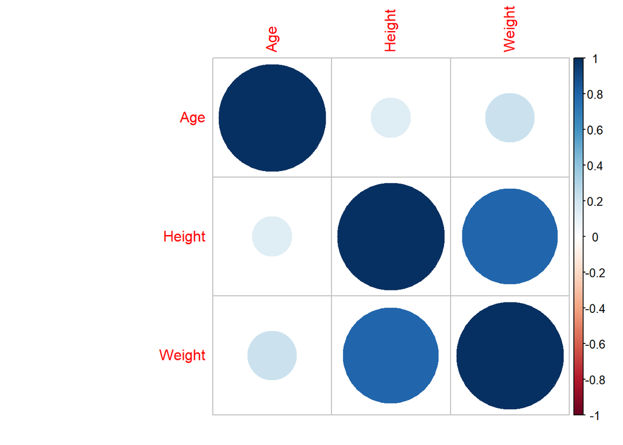

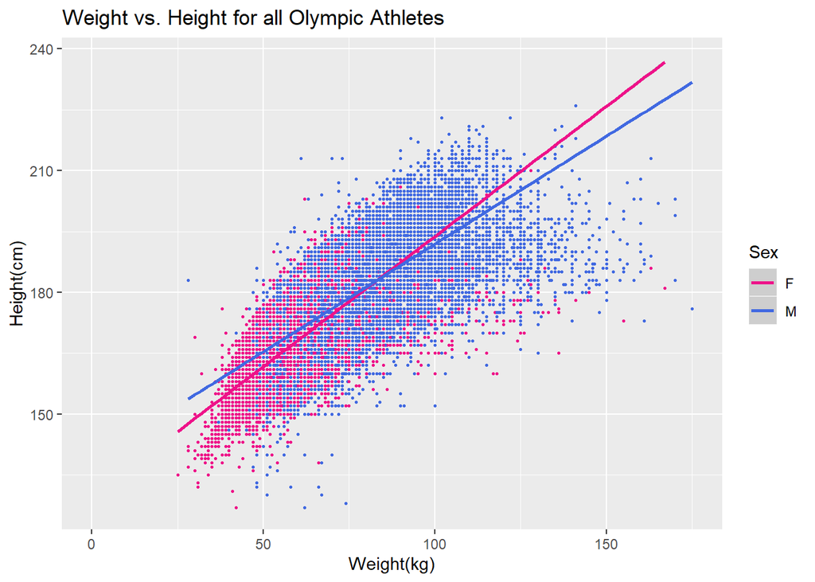

## 3.2 Does the average Age, Height, or Weight different between olympic medalists and non-medalists?

In order to determine whether age, height and weight differ between medalists and non-medalists, we have performed two-sample t-tests with the groups being athletes that have won a medal and athletes that have not won a medal. These tests were performed on male and female athlete populations separately because in our previous analysis from Project 1, we found that the mean age, height, and weight of males significantly differs from that of females (two-sample t-test).

### 3.2.1 T-Test Results

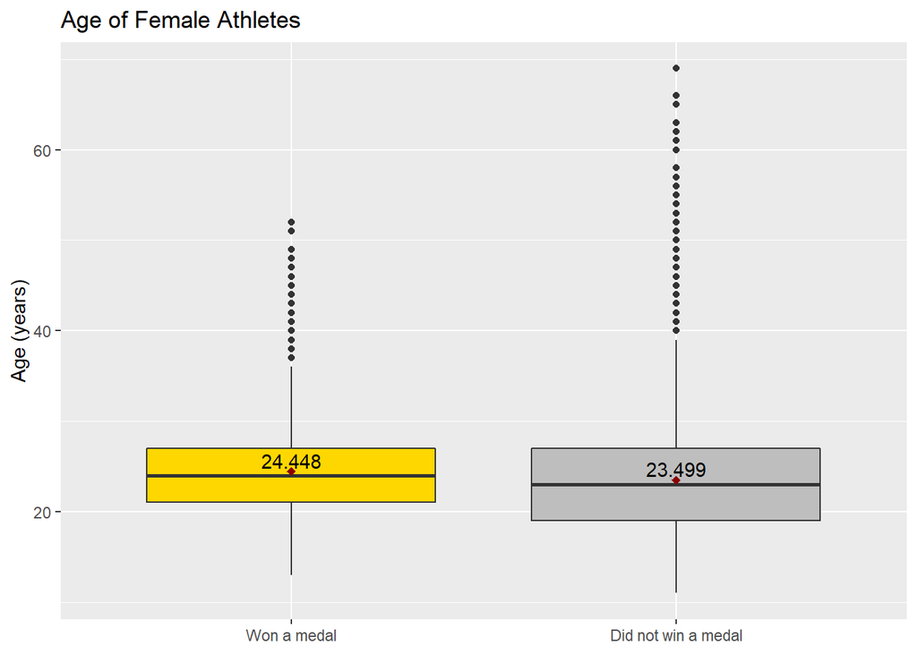

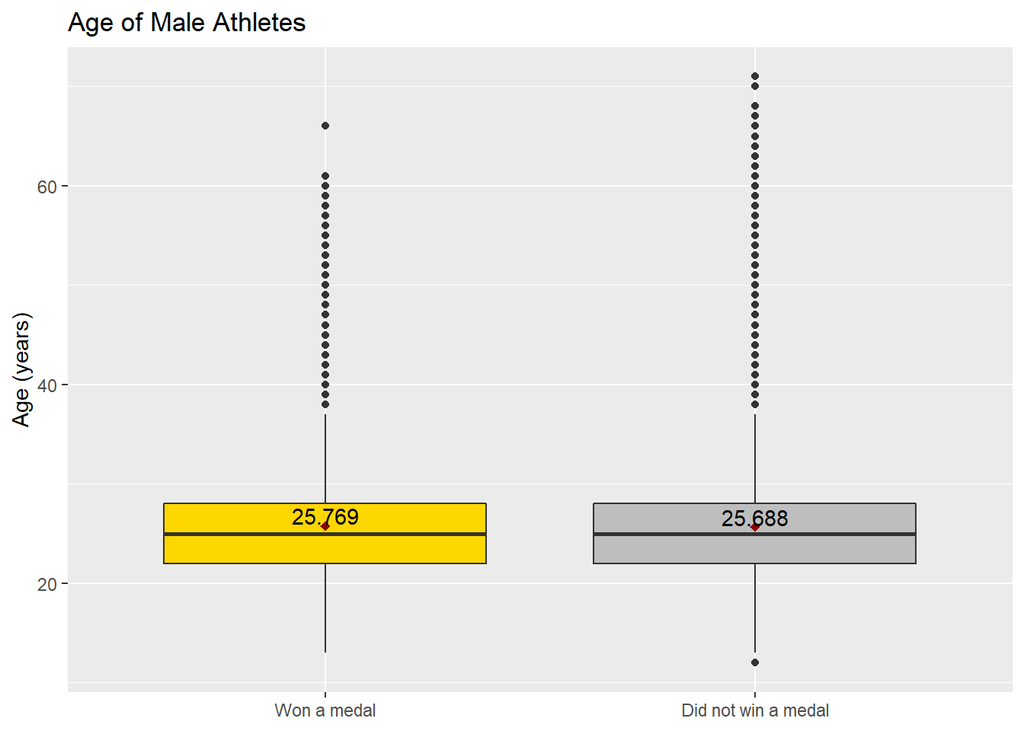

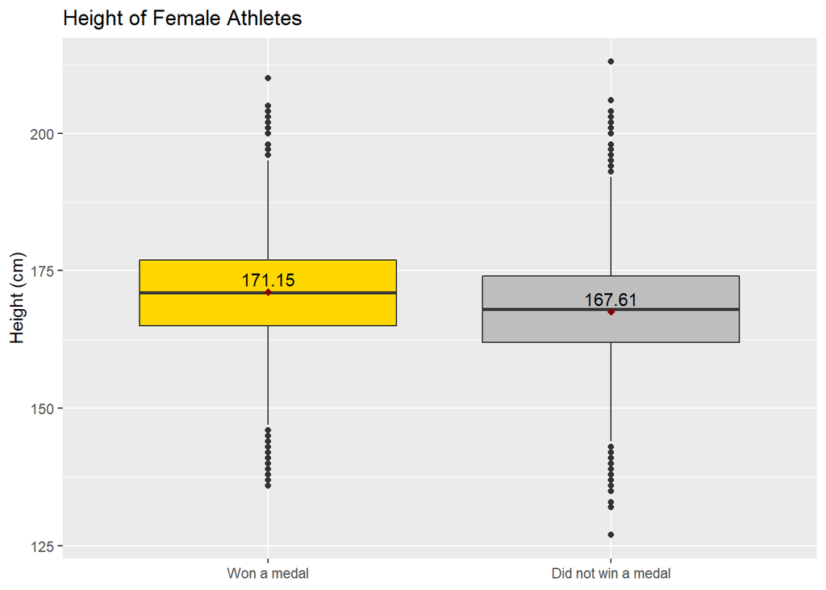

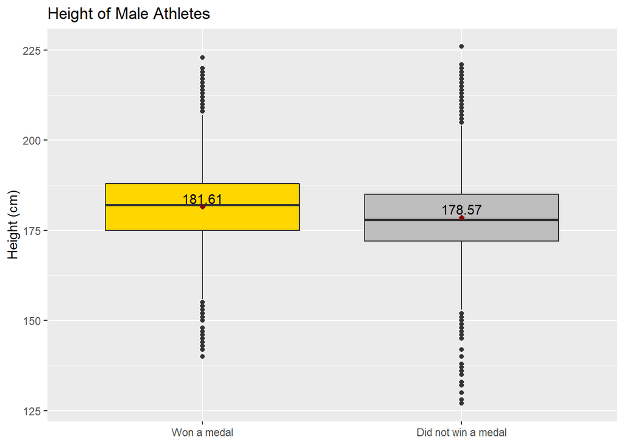

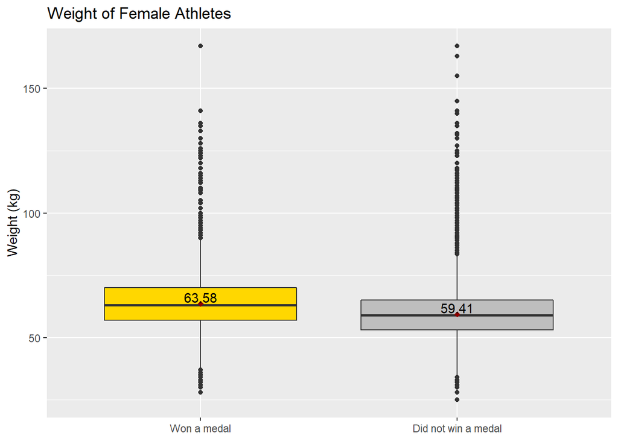

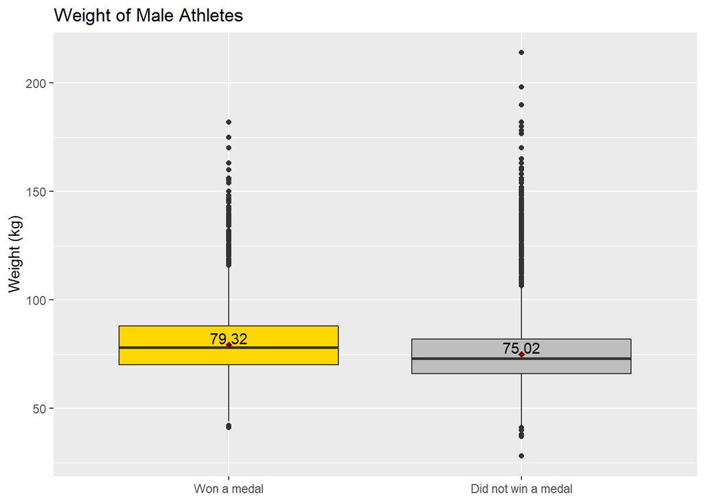

## 3.3 Principal Component Analysis

In order to further confirm which variables to include in the regression analysis, we performed Principle Component Analysis. Plots show us, once again, that height and weight are highly correlated. Age is almost orthogonal to these two variables. Thus, in the regression analysis we will include age and either height or weight, not both, to avoid multicollinearity.

```
## Importance of components:
##                          PC1   PC2    PC3
## Standard deviation     1.365 0.942 0.5002
## Proportion of Variance 0.621 0.296 0.0834
## Cumulative Proportion  0.621 0.917 1.0000
```

```
##           PC1    PC2     PC3
## Age    -0.342  0.938  0.0499
## Height -0.659 -0.278  0.6988
## Weight -0.670 -0.206 -0.7136
```

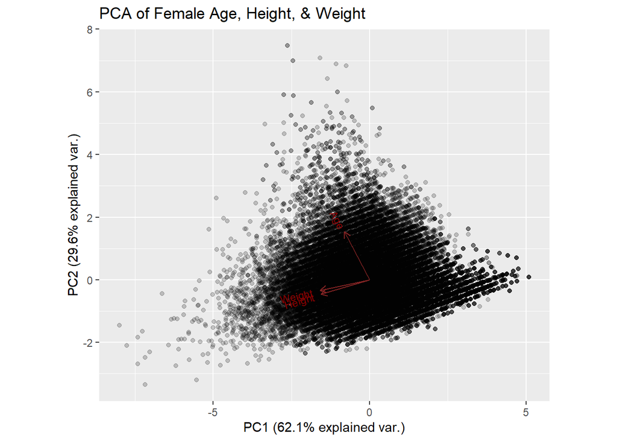

```
## Importance of components:
##                          PC1   PC2    PC3
## Standard deviation     1.321 0.998 0.5086
## Proportion of Variance 0.582 0.332 0.0862
## Cumulative Proportion  0.582 0.914 1.0000
```

```
##          PC1     PC2     PC3
## Age    0.119  0.9881  0.0973
## Height 0.698 -0.1529  0.6996
## Weight 0.706 -0.0152 -0.7079
```

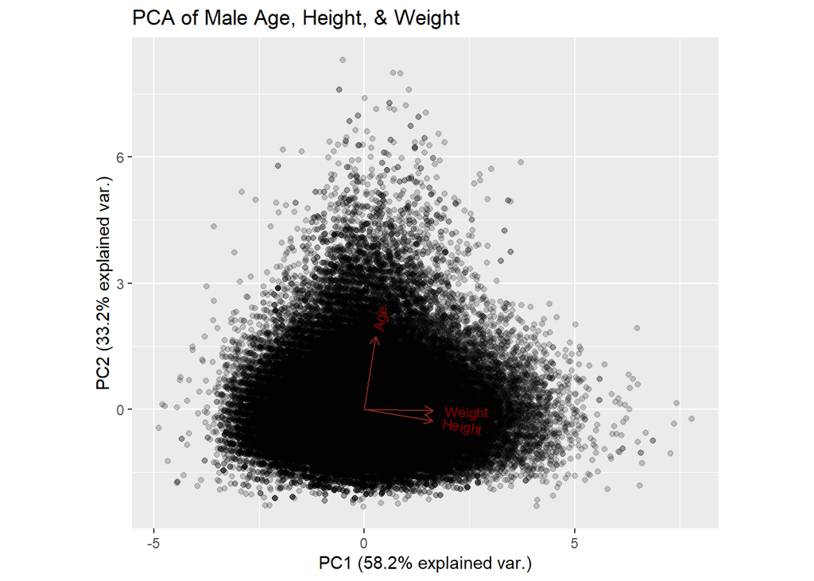

## 3.4 Logistic Regression

In order to evaluate the extent to which age, height, and weight determine whether an athlete wins an olympic medal, we will perform multiple-Logisitic Regressions. This method was chosen because the dependent variable, ‘Medal’ is categorical: ‘Won a medal’, or ‘Did not win a medal’. The independent variables include Age and Weight. Height was not included due to its strong correlation with Weight.

According to the results, in the female Logistic Regression, age and weight have significant p-values (<0.05).As female age increases by one unit, log odds of winning a medal increases by 0.015. As female weight, and therefore height, increases by one unit, log odds of winning a medal increases by 0.031. These results align with our t-tests for female athletes.

The male logistic regression yeilds similar results to that of females, however, the coefficient for Age reveals a negative relationship with winning a medal. As male age increases by one unit, log odds of winning a medal decreases by 0.004. As male weight, and thus height, increases by one unit, log odds of winning a medal increases by 0.021.

### 3.4.1 Testing the model

VIF values for each of these models are around 7, which is below the general threshold of 10. In the female model, the Area under the curve is 0.6243, indicating this is not a great classifier. On top of that, this model produces a McFadden value of 2.24%, quite a low value. In the male model, the ROC AOC score is 0.577, and the McFadden value is 1.38%. Again, these values indicate this is not a good model in predicting medals won.

## 3.6 Case Study I: Gymnastics

Gymnastics is one of the most popular Olympic Sports to watch. As we have seen in our graphs, and as is common knowledge, gymnasts are generally younger, shorter, and lighter than most other athletes.Thus, we would like to determine whether these independent variables play a significant role in an gymnasts’ chance of earning an olympic medal.

### 3.6.1 Does Age, Height, Weight differ between Gymnast medalists and non-medalists?

In a similar fashion to our previous analysis of all athletes, we would like to determine whether medlists and non-medalists significantly vary in their average age, height, or weight. We performed two-sample t-tests in the same manner.

#### 3.6.1.1 Age

The average age of male gymnasts is 23.79, while that of all other athletes is 25.90. Clearly, this is not as great of a difference compared to that of females. In the t-test between male gymnast medalists and non-medalists, the p-value much greater that 0.05, thus we cannot reject the null hypothesis and conclude that the average age does not differ between the two groups.

From these results, we can infer that age plays a bigger factor in women’s gymnastics than it does in men’s gymnastics.

#### 3.6.1.2 Height

From these results, we can infer that height plays a significant role in both men and women’s gymnastics. It seems that shorter gymnasts perform better.

### 3.6.2 Gymnastics Logistic Regression

According to the Gymnastics Logistic model we have built with Age and Height predicting whether the athlete wins a medal, for females, age and height have significant p-values. For males, only height has a significant p-value. As females increase age by one unit, the log odds of winning a medal increases by 0.05. As female gymnast height increases by one unit, log odds of winning a medal decreases by 0.029. These results align with our t-test results for female gymnasts: the average age of gymnasts medalists is older than that of non-medalists, and gymnast medalists are shorter (and lighter) than non-medalists. In the case of Men’s Gymnastics, age does not significantly predict winning a medal. As height (and thus weight) increases by one unit, log odds of winning a medal decreases by 0.06. Again, these results are consistent with our Men’s Gymnastics t-tests. Shorter/lighter male gymnasts are more likely to win an olympic medal, as are females.

However, in testing these models, the area under the curve is 0.5786 and 0.5936 for females and males, respectively. Additionally, McFadden values are quite low at 0.73% and 1.26%. From this we conclude that these are not good models of predicting gymnastics olympic medalling. Perhaps with additional independent variables such as, years of training, ethnicity, muscle mass, etc. we would be able to create a better model.

## 3.7 Case study II: Weightlifting

Our next case study, weightlifting was interesting because on our boxplot of average height and weight across all sports, for both males and females, weightlifters were on the lower-end for height and higher-end for weight when compared to all other sports. The graph of Weight vs. Height printed below depicts the relationship between those of weightlifters in red and all other athletes in gray. Clearly, the relationship is not as linear when compared to other athletes.

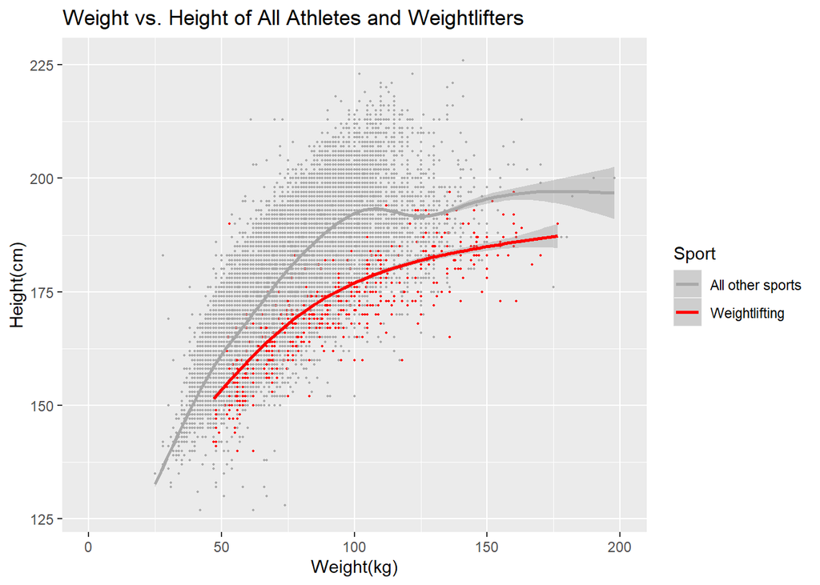

### 3.7.1 Weightlifting T-Tests

In a similar fashion to our other case study and previous analysis of all athletes, we have performed t-tests to evaluate the difference between weightlifting olympic medalists and non-medalists age, height, and weight. Our results reveal that the average age, height, and weight of female weightlifting medalists does not significantly differ from that of non-medalists. Males have similar results, however the male weightlifting medalists have a significant p-value, thus significantly different mean for Weight compared to non-medalists. Male weightlifting medalists are on average 82.91kg, while non-medalists average 79.77kg. So, it may be beneficial for male weightlifters to be heavier if they want to win a medal.

### 3.7.2 Weightliftiing Logistic Regressions

In our logistic models for weightlifters, we have included Age, Height, and Weight. In this case, because height and weight are less highly correlated, we have included both variables in the model. The results for female weightlifters reveal that age, height, and weight are not signifcant predictors of winning a weightlifting medal. Conversely, for males, both height and weight had significant p-values. As male weightlifters’ height increases by one unit, log odds of winning a medal decrease by 0.033. As male weightlifters’ weight increases by one unit, log odds of winning a medal increases by 0.016. This means that shorter, heavier male weightlifters are more likely to win an olympic medal. This is quite interesting consdiering it differs from our results of all altheltes and Case Study I. This proves that age, height, and weight affects athletes of all sports differently. Again, these models are not good according to the AOC and McFadden values, so our results cannot be interpreted as strong conclusions.

# 4 SMART QUESTION III:

## 4.1 Does GDP determine winning/losing? Is GDP a good predictor to predict whether an athlete wins a medal?

To make things more interesting and to deepen our analysis, we decided to introduce GDP as a new variable in this project. We would like to see if GDP has an effect on how well an athlete performs in an event - similar to what we did for sex, age, height, and weight in the previous project. Moreover, we want to see whether GDP influences the gender distribution of a countires athletes, and the overall number of participants per country. Finally, we want to test whether GDP is a good predictor for medals won. In this final part of the analysis we will build several models with GDP included as a feature. In summary, this part of the paper will try to answer the following questions:

- How does GDP determine statistics in the Olympics?
- Is GDP a good predictor for medals won?

In order to answer these questions, we merged Summer_with_NAs â the dataset on the Olympics we have used so far in our analysis â with the GDP dataset retrieved from the World Bank website. Prior to doing that, we merged Summer_with_NAs with the Name of Country (NOC) dataset â which contains the NOC codes for the countries â by the NOC column. Summer_with_NAs has column called Team which contains the names of the country an athlete comes from, but it also contains names of different teams, such as rowing teams, gymnastic teams, and so on, which is an irrelevant information for our analysis. Therefore, we merged Summer_with_NAs with NOC to have a more accurate columns that contain the country names and we deleted the Team column. Finally, we merged the new dataset with the GDP dataset by country and year.

It is relevant to mention that some data cleaning was necessary to make the new data frame easier to work on. Additionally, we scaled the GDP variable using the in-built R function scale(), which scaled it on a scale from -1 to 6. Roughly speaking, each GDP unit is worth 300 billion dollars. We also deleted all the rows with NAs to work on a more complete data frame. The following is the structure of Summer_GDP_nona, the data frame we will be using for most of the analysis in this part:

```
## 'data.frame':    137501 obs. of  16 variables:
##  $ Country: Factor w/ 206 levels "Afghanistan",..: 1 1 1 1 1 1 1 1 1 1 ...
##  $ Year   : int  1960 1960 1960 1960 1960 1960 1960 1960 1960 1960 ...
##  $ NOC    : Factor w/ 230 levels "AFG","AHO","ALB",..: 1 1 1 1 1 1 1 1 1 1 ...
##  $ ID     : int  29626 109486 59346 39922 109486 106372 58364 59102 128736 133717 ...
##  $ Name   : Factor w/ 134732 levels "  Gabrielle Marie \"Gabby\" Adcock (White-)",..: 118086 447 90331 439 447 45049 90345 6340 449 5294 ...
##  $ Sex    : Factor w/ 2 levels "F","M": 2 2 2 2 2 2 2 2 2 2 ...
##  $ Age    : int  28 20 24 22 20 23 20 35 20 20 ...
##  $ Height : int  168 178 171 172 178 170 166 166 179 168 ...
##  $ Weight : num  73 68 78 70 68 58 62 66 75 58 ...
##  $ Games  : Factor w/ 51 levels "1896 Summer",..: 22 22 22 22 22 22 22 22 22 22 ...
##  $ Season : Factor w/ 2 levels "Summer","Winter": 1 1 1 1 1 1 1 1 1 1 ...
##  $ City   : Factor w/ 42 levels "Albertville",..: 29 29 29 29 29 29 29 29 29 29 ...
##  $ Sport  : Factor w/ 66 levels "Aeronautics",..: 66 6 66 6 6 6 66 66 6 6 ...
##  $ Event  : Factor w/ 765 levels "Aeronautics Mixed Aeronautics",..: 758 77 753 91 91 94 739 749 78 91 ...
##  $ Medal  : Factor w/ 2 levels "Loser","Winner": 1 1 1 1 1 1 1 1 1 1 ...
##  $ GDP    : num [1:137501, 1] -0.449 -0.449 -0.449 -0.449 -0.449 ...
##  - attr(*, "na.action")= 'omit' Named int  17 18 19 20 22 23 30 31 33 35 ...
##   ..- attr(*, "names")= chr  "17" "18" "19" "20" ...
```

### 4.1.1 Does GDP determine winning/losing?

The first questions we attempt to answer in this part is if GDP influences whether an athlete earns a medal and if GDP can be a good predictor for that. To see if GDP has an effect on whether an athlete wins a medal we firstly display the data in a boxplot.

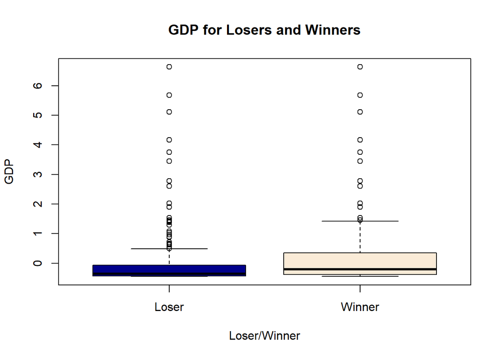

Next, we run an ANOVA test, which is the best test in this case because we need to compare the means of a numerical variable and a categorical variable.

The null hypothesis of this test is the following: the people who won a medal and people who did not win a medal have the same mean for GDP.

From the ANOVA test we got a really small p-value which is way smaller than our confidence level 0.05 and therefore we reject the null hypothesis and conclude that GDP has an effect on whether an athlete earns a medal. As we can see visually from the boxplot, athletes who won a medal tend to come from countries with higher GDP.

### 4.1.2 Is GDP a good predictor to predict whether an athlete wins a medal?

#### 4.1.2.1 Logistic Regression

Then, we tested GDP as a predictor by building a Generalized Linear Model with scaled GDP as a predictor and Winner/Loser as the Y variable. In this case, the Generalized Linear Model is the best model to use because we are trying to predict Winner/Loser, which is a dichotomous variable.

```
##
## Call:
## glm(formula = Medal ~ GDP, family = "binomial", data = Summer_GDP_nona)
##
## Deviance Residuals:
##    Min      1Q  Median      3Q     Max
## -1.240  -0.527  -0.512  -0.508   2.055
##
## Coefficients:
##             Estimate Std. Error z value            Pr(>|z|)
## (Intercept) -1.84688    0.00796  -232.1 <0.0000000000000002 ***
## GDP          0.30009    0.00580    51.8 <0.0000000000000002 ***
## ---
## Signif. codes:  0 '***' 0.001 '**' 0.01 '*' 0.05 '.' 0.1 ' ' 1
##
## (Dispersion parameter for binomial family taken to be 1)
##
##     Null deviance: 111880  on 137500  degrees of freedom
## Residual deviance: 109468  on 137499  degrees of freedom
## AIC: 109472
##
## Number of Fisher Scoring iterations: 4
```

From this model we can see that for every unit gain in scaled GDP, the ln(odds-ratio) of winning a medal increases by 0.3. All the p-values that we got in this model are very small and that means that the values we found are statistically significant.

To evaluate whether our model is good, we are going to perform the following tests:

- Receiver-Operator-Characteristic curve and Area-Under-Curve:

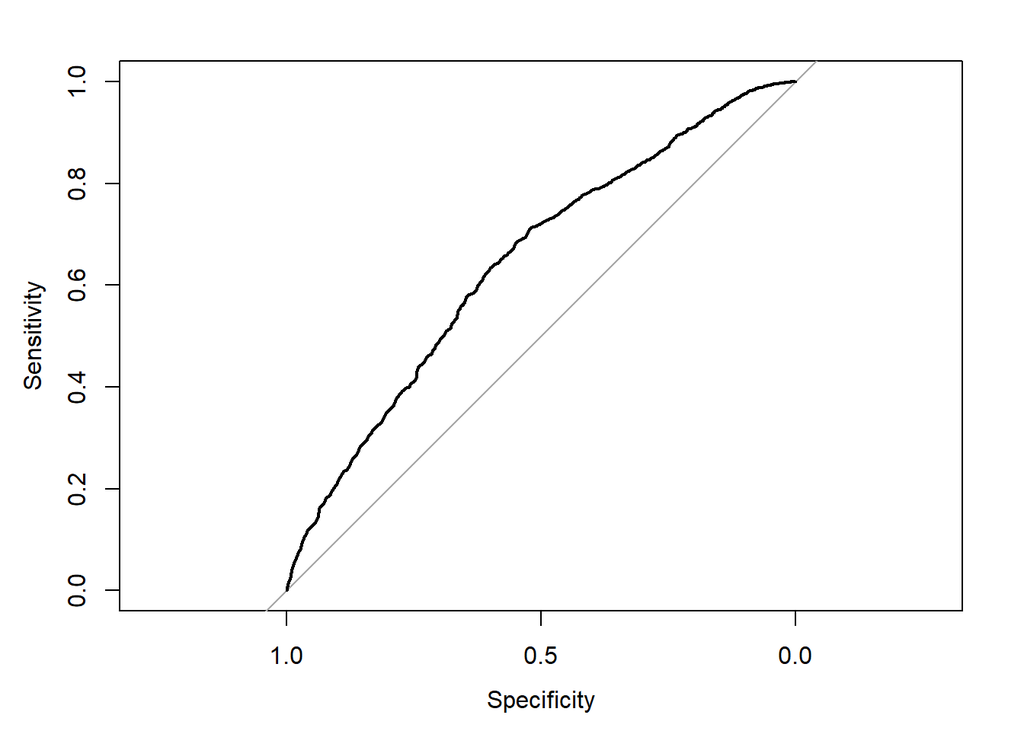

The area-under-curve for this model is 0.645, which is less than 0.8. Althought 0.645 is not much smaller than 0.8, this means that this model is not a good fit.

- McFadden: with the McFadden value of 0.022 only 2% of the variation in y is explained by the explanatory variables in the model, which is not good.

Since the first model we built is not a good model overall, we built a second Generalized Linear Model including more variables to attempt to create a better model. We included GDP, Weight, Age, and Sex, and we left Height out as it is strongly correlated with Weight.

```
##
## Call:
## glm(formula = Medal ~ GDP + Weight + Age + Sex, family = "binomial",
##     data = Summer_GDP_nona)
##
## Deviance Residuals:
##    Min      1Q  Median      3Q     Max
## -2.003  -0.558  -0.499  -0.441   2.371
##
## Coefficients:
##              Estimate Std. Error z value            Pr(>|z|)
## (Intercept) -3.107034   0.047417  -65.53 <0.0000000000000002 ***
## GDP          0.277683   0.005914   46.95 <0.0000000000000002 ***
## Weight       0.021702   0.000571   38.01 <0.0000000000000002 ***
## Age          0.001177   0.001412    0.83                 0.4
## SexM        -0.510310   0.019144  -26.66 <0.0000000000000002 ***
## ---
## Signif. codes:  0 '***' 0.001 '**' 0.01 '*' 0.05 '.' 0.1 ' ' 1
##
## (Dispersion parameter for binomial family taken to be 1)
##
##     Null deviance: 111880  on 137500  degrees of freedom
## Residual deviance: 107954  on 137496  degrees of freedom
## AIC: 107964
##
## Number of Fisher Scoring iterations: 4
```

From this model we can see that almost all the variables have positive values, apart from Sex, which is negative. According to the model, if an athlete is a male the ln(odds-ratio) of his chances of winning a medal decrease by 0.5, which seems a little off, as male athletes won more medals than female athletes. In addition, we got significant p-values for all the variables but Age, whose p-value is 0.4, and therefore it is not statistically significant.

To evaluate whether our model is good, we are going to perform the following tests:

- Receiver-Operator-Characteristic curve and Area-Under-Curve:

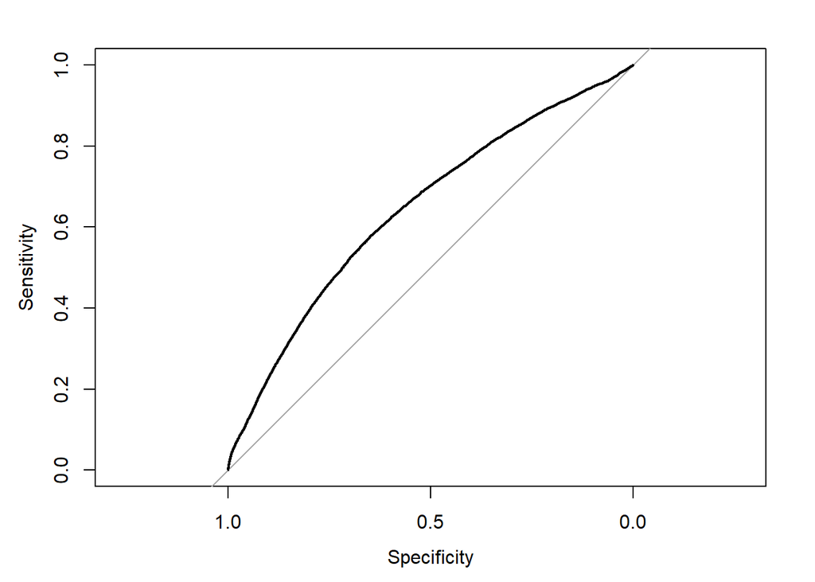

The area-under-curve for this model is 0.644, which is less than 0.8. Althought 0.644 is not much smaller than 0.8, this means that this model is not a good fit.

- McFadden: In this case, we got a McFadden value of 0.035, whihc means that only 3% of the variation in y is explained by the explanatory variables in the model, which is not good.
- We are aslo going to run the Aikake information criterion to compare the two models and see which one of the two is better. We got 109471.573 for the first model and 107964.263 for the second model.That means that the second model is better as its value is lower. However, overall our second model is not a good model either. To improve it, we would probably need to add additional variables to the model.

#### 4.1.2.2 k-Nearest Neighbors (KNN)

As logistic regression did not prove to be a good model to predict Winner/Loser, we decided to build another model using the k-Nearest Neighbors (KNN) algorithm. We ran three KNN models using the following three different values: 3,5, and 7. To build them, we used Age, Height, Weight, and GDP as predictors and Winner/Loser as the Y variable.

The cross table for the first model, with k=3, is the following:

```
##
##
##    Cell Contents
## |-------------------------|
## |                       N |
## |           N / Row Total |
## |           N / Col Total |
## |         N / Table Total |
## |-------------------------|
##
##
## Total Observations in Table:  45324
##
##
##                 | oly_pred1
## oly.testLabels1 |     Loser |    Winner | Row Total |
## ----------------|-----------|-----------|-----------|
##           Loser |     36546 |      2334 |     38880 |
##                 |     0.940 |     0.060 |     0.858 |
##                 |     0.862 |     0.793 |           |
##                 |     0.806 |     0.051 |           |
## ----------------|-----------|-----------|-----------|
##          Winner |      5834 |       610 |      6444 |
##                 |     0.905 |     0.095 |     0.142 |
##                 |     0.138 |     0.207 |           |
##                 |     0.129 |     0.013 |           |
## ----------------|-----------|-----------|-----------|
##    Column Total |     42380 |      2944 |     45324 |
##                 |     0.935 |     0.065 |           |
## ----------------|-----------|-----------|-----------|
##
##
```

The cross table for the first model, with k=5, is the following:

```
##
##
##    Cell Contents
## |-------------------------|
## |                       N |
## |           N / Row Total |
## |           N / Col Total |
## |         N / Table Total |
## |-------------------------|
##
##
## Total Observations in Table:  45324
##
##
##                 | oly_pred2
## oly.testLabels1 |     Loser |    Winner | Row Total |
## ----------------|-----------|-----------|-----------|
##           Loser |     37628 |      1252 |     38880 |
##                 |     0.968 |     0.032 |     0.858 |
##                 |     0.861 |     0.762 |           |
##                 |     0.830 |     0.028 |           |
## ----------------|-----------|-----------|-----------|
##          Winner |      6054 |       390 |      6444 |
##                 |     0.939 |     0.061 |     0.142 |
##                 |     0.139 |     0.238 |           |
##                 |     0.134 |     0.009 |           |
## ----------------|-----------|-----------|-----------|
##    Column Total |     43682 |      1642 |     45324 |
##                 |     0.964 |     0.036 |           |
## ----------------|-----------|-----------|-----------|
##
##
```

The cross table for the first model, with k=7, is the following:

```
##
##
##    Cell Contents
## |-------------------------|
## |                       N |
## |           N / Row Total |
## |           N / Col Total |
## |         N / Table Total |
## |-------------------------|
##
##
## Total Observations in Table:  45324
##
##
##                 | oly_pred3
## oly.testLabels1 |     Loser |    Winner | Row Total |
## ----------------|-----------|-----------|-----------|
##           Loser |     38204 |       676 |     38880 |
##                 |     0.983 |     0.017 |     0.858 |
##                 |     0.860 |     0.752 |           |
##                 |     0.843 |     0.015 |           |
## ----------------|-----------|-----------|-----------|
##          Winner |      6221 |       223 |      6444 |
##                 |     0.965 |     0.035 |     0.142 |
##                 |     0.140 |     0.248 |           |
##                 |     0.137 |     0.005 |           |
## ----------------|-----------|-----------|-----------|
##    Column Total |     44425 |       899 |     45324 |
##                 |     0.980 |     0.020 |           |
## ----------------|-----------|-----------|-----------|
##
##
```

The first KNN model, with k=3, has an accuracy of 81.979. The second model, with k=5, has an accuracy of 83.881. The third model, with k=7, has an accuracy of 84.783. They are all rather accurate, but the third model is the most accurate of the three. As we can see from the cross tables, all the three models are good at predicting losers and not very good at predicting winners. If we applied it to the real world, it would make sense as just a small part of the athletes wins a medal, whereas the majority does not.

## 4.2 Does GDP have an effect on whether and athlete is male or female?

In the second part of this section, we tested whether GDP has an effect on the gender of the athletes. Again, we display the data in a boxplot and then we run an ANOVA test, which is the best test as we are comparing the means of a numerical variable and a categorical variable.

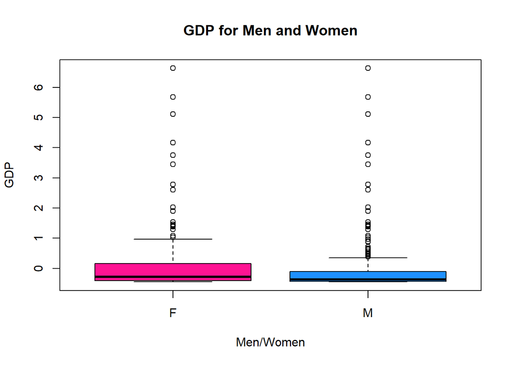

The null hypothesis of this test is the following: the female athletes and male athletes have the same mean for GDP.

From the ANOVA test we got a really small p-value which is way smaller than our confidence level 0.05 and therefore we reject the null hypothesis and conclude that GDP has an effect on whether female athletes partecipate to the olympics. As we can see visually from the boxplot, the GDP mean for female athletes is higher than the GDP mean for male athletes. Therefore we can conclude that female athletes tend to partecipate more often if they come from a country with a higher GDP.

## 4.3 Does GDP have an effect on the number of participants?

Finally, in the last part of this section, we tested whether GDP influences the number of participants to the Olympic Games. To conduct this analysis, we created a new data frame called SummerGDPFreq by creating a frequency table of countries by year and merging it with the GDP dataset. As displayed below, this new data frame no longer contains the name of the athletes along with their features, but it only has the name of the countries, the year, the number of participants for each country each year and GDP.

```
## 'data.frame':    2177 obs. of  4 variables:
##  $ Country     : Factor w/ 206 levels "Afghanistan",..: 1 1 1 1 1 1 1 1 1 1 ...
##  $ Year        : Factor w/ 15 levels "1960","1964",..: 1 2 3 4 5 6 12 13 14 15 ...
##  $ Participants: int  16 2 5 3 0 11 4 4 6 3 ...
##  $ GDP         : num [1:2177, 1] -0.198 -0.198 -0.197 -0.197 -0.196 ...
##   ..- attr(*, "scaled:center")= num 182997864874
##   ..- attr(*, "scaled:scale")= num 920372312516
```

```
##       Country Year Participants    GDP
## 1 Afghanistan 1960           16 -0.198
## 2 Afghanistan 1964            2 -0.198
## 3 Afghanistan 1968            5 -0.197
## 4 Afghanistan 1972            3 -0.197
## 5 Afghanistan 1976            0 -0.196
## 6 Afghanistan 1980           11 -0.195
```

The following graphs present the correlation among the variables in “SummerGDPFreq” in different ways:

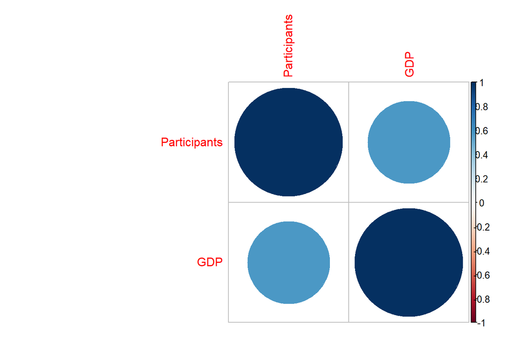

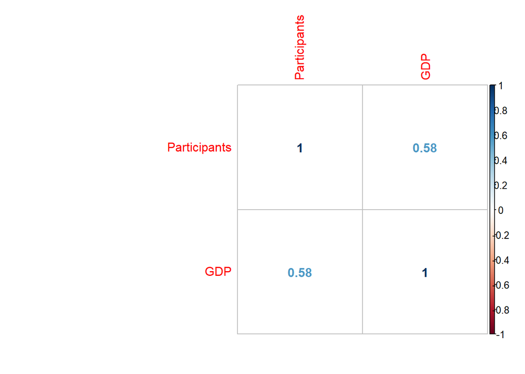

We the built a linear regression model using scaled GDP as the predictor and Number of Participants as the dependent variable. In this case, the linear model was the best model to use as we are trying to predict a numerical variable which is correlated with its predictor.

```
##
## Call:
## lm(formula = Participants ~ GDP, data = SummerGDPFreq)
##
## Residuals:
##    Min     1Q Median     3Q    Max
## -799.0  -46.1  -39.0   -2.8  968.7
##
## Coefficients:
##             Estimate Std. Error t value            Pr(>|t|)
## (Intercept)    63.16       2.18    29.0 <0.0000000000000002 ***
## GDP            72.26       2.18    33.2 <0.0000000000000002 ***
## ---
## Signif. codes:  0 '***' 0.001 '**' 0.01 '*' 0.05 '.' 0.1 ' ' 1
##
## Residual standard error: 102 on 2175 degrees of freedom
## Multiple R-squared:  0.336,  Adjusted R-squared:  0.335
## F-statistic: 1.1e+03 on 1 and 2175 DF,  p-value: <0.0000000000000002
```

After we ran our linear regression model, we got an intercept of 63.2 and a slope of 72.3. This means that for an increase of one point for the scaled GDP, which is worth billions of dollars, we expect an increase of more than 72 participants in total on average. Additionally, we got a really tiny p-value for the slope. Therefore, we reject the null hypotheisis, which is that the intercept and the slope is equal to 0, and we say that our slope is statistically significant.

Finally, we got an R-squared value of 0.336. This means that our model accounts for approximately 34% of the variance.

# 5 Conclusion

Throughout this analysis we obtained a better insight on the Olympic Games dataset and we were able to understand which features contained in the dataset have an effect on whether an athlete earns a medal, on the gender of the athletes, and on the number of participants. Additionally, adding GDP as a variable allowed us to get a more complete picture of the Olympics world.

SMART Question 1 showed that hosting the Olympics always increases the amount of medal won compared to previous years and that host countries seem to perform better in years after the Olympics they hosted. Yet, some countries do not exhibit these common trends. This shows that occasionally the host-effect doesnt actually motivate the host athletes to perform better. Some teams also dont continue their winning streak in the Olympic games after hosting, we can conclude that the Olympics are not important enough in these countries for hosting to have a lasting effect.

Smart Question 2 showed that age, height, and weight do determine winning of Olympic medals; however, it varies by gender and by sport. For female athletes, increases in age, height, weight increase the chances of winning a medal. For male athletes, increases in weight and height increase the chances of winning a medal; however, an increase in age lowers the chances of winning.

Smart Question 3 showed that GDP seems to have an effect on whether an athlete earns a medal, on the gender of the athletes, and on the number of participants sent by each country to the Olympics. As most of the models we built using GDP as a variable were not good, we can conclude that GDP per se is not a great predictor, but it definitely made our analysis more thorough and complete. We can conclude that GDP does not only influence sectors that are strictly related to it, such as economy, but it also has an influence on sports.

# 6 Bibliography

Griffin, R. (2019). 120 years of Olympic history: athletes and results. [online] Kaggle.com. Available at: https://www.kaggle.com/heesoo37/120-years-of-olympic-history-athletes-and-results [Accessed May 2018].

World Bank. GDP Dataset (current US$). Available at: https://data.worldbank.org/indicator/NY.GDP.MKTP.CD [Accessed November 2019]